# 实验2 回归模型

## 罗瑞 2210529

**基本要求** 将数据集winequality-white.csv按照4:1划分为训练集和测试集。

1. 构造线性回归模型，并采用批量梯度下降（BGD）和随机梯度下降（SGD）进行优化；输出训练集和测试集的均方误差（MSE），画出MSE收敛曲线。
2. 对于批量梯度下降和随机梯度下降，采用不同的学习率并进行MSE曲线展示，分析选择最佳的学习率。 特别需要注意：
- 划分数据集时尽可能保持数据分布的一致性，保持样本类别比例相似，可采用分层采样的方式。
- 需要对数据集进行一定的预处理

**中级要求**

探究回归模型在机器学习和统计学上的差异。 回归模型在机器学习领域和统计学领域中都十分常用，而且使用方法也相似，但其实际的含义具有本质的区别。我们希望同学们从回归模型的角度更加充分地理解机器学习和统计学的区别。

**高级要求**

编程实现岭回归算法，求解训练样本的岭回归模型，平均训练误差和平均测试误差（解析法、批量梯度下降法和随机梯度下降法均可）。

## 初级要求实现：基础BGD和SGD线性回归

### 1. 数据集预处理

首先我需要对 winequality-white.csv 数据集进行预处理，重要的操作包括训练集、测试集的划分、标准化和偏置项的增加（为了向量相乘方便）。

**数据划分**：通过 pd.read_csv 读取 winequality-white.csv 数据集并将其转化为 NumPy 数组之后，首先分别通过X = data[:, :-1]以及y = data[:, -1] 来划分特征和目标。使用 train_test_split 按照 4:1 的比例划分数据。通过 stratify=y 参数确保训练集和测试集中的标签分布一致，从而保持数据的类别分布一致性，实现了数据集分层采样。 **数据标准化**：使用 StandardScaler 对特征进行标准化，使数据的每个特征均值为 0，方差为 1，消除特征的量纲差异，且只对训练集进行 fit_transform，即计算训练集的均值和标准差，并对其进行标准化，对测试集使用训练集的均值和标准差对测试集标准化，以保持一致性性，在代码上实现为只进行 transform。

**偏置项添加**：使用 np.hstack 在训练集和测试集的特征矩阵左侧分别添加一个全为 1 的列（偏置项），便于向量相乘。

```python
import pandas as pd
import numpy as np
from sklearn.model_selection import train_test_split
from sklearn.preprocessing import StandardScaler
import matplotlib.pyplot as plt
```

```python
data = pd.read_csv("winequality-white.csv")
# （4898，12）

# 转化为numpy数组
data = np.array(data)

# 划分特征和标签值
X = data[:, :-1]
y = data[:, -1]

# 数据分层划分，按照4:1划分为训练集和测试集
# train_test_split 中的 stratify=y 参数可以确保分层采样。
# stratify 的作用是根据目标变量 y 中各个类别的比例，
# 按相同比例划分数据集，从而在训练集和测试集中保持数据的类别分布一致。
X_train, X_test, y_train, y_test = train_test_split(X, y, test_size=0.2, stratify=y, random_state=42)

# 特征标准化
# StandardScaler 是一种常用的标准化方法，
# 它通过将数据进行均值为 0、方差为 1 的处理来消除特征量纲的差异。
scaler = StandardScaler()

# fit 阶段:计算每个特征在训练集上的均值 μ 和标准差 σ。
# 这一步只对训练集进行，因为测试集的数据是未知的，不能提前用它来影响标准化过程。
# 这样可以确保模型在实际应用中只依赖于训练集数据，符合机器学习的原则。
# transform 阶段:
# 利用训练集计算得到的均值和标准差对训练集进行标准化
X_train = scaler.fit_transform(X_train)
# 为了向量相乘方便，在训练集X左侧添加全为1的一列
X_train = np.hstack([np.ones((X_train.shape[0], 1)), X_train])

# 对测试集进行标准化，但 不重新计算 均值和标准差，而是使用在训练集上计算得到的均值 μ 和标准差 σ
# 这样做的目的是保持测试集与训练集在相同的标准化尺度上，确保模型在训练和测试阶段的一致性。
X_test = scaler.transform(X_test)
# 在测试集X左侧也添加全为1的一列
X_test = np.hstack([np.ones((X_test.shape[0], 1)), X_test])
```

### 2. BGD和SGD线性回归算法的设计

为方便实现线性回归模型，我设计了一个类，能够通过训练集进行训练，其中提供了两种优化方法：批量梯度下降（BGD） 和 随机梯度下降（SGD），并且可对输入X进行预测：$$\hat{y}=X\theta $$,并与此同时可分别记录训练集以及测试集中的MSE误差。

**算法BGD介绍：**

批量梯度下降（BGD）使用整个训练集（所有样本）来计算损失函数相对于参数 theta 的梯度。它通过以下步骤更新参数：

**1. 预测值计算**：利用当前的 theta 进行预测，即得到 $$\hat{y} = X \theta$$ **2. 计算梯度**：因为 均方误差损失函数为$$J(\theta)=\frac1m\sum(y-\hat{y})^2$$，计算得到关于$X$的梯度为 $$\nabla_\theta J(\theta)=-\frac2mX^T(y-\hat{y})$$，其中 X 是输入特征矩阵，y 是真实目标标签，m 是样本数量。

**3. 更新参数**：按照 $$\theta = \theta - \alpha \times \nabla_\theta J(\theta)$$ 的公式更新参数，使得损失函数逐渐减小,趋于收敛。

```python
def batch_gradient_descent(self):
    gradients = 1 / self.m * self.X_train.T.dot(self.X_train.dot(self.theta) - self.y_train)
    self.theta -= self.alpha * gradients
```

**算法SGD介绍：** 随机梯度下降在每次迭代中，随机选择一个样本来计算梯度并更新参数。这种方法会更频繁地更新 theta，但每次更新的方向并不一定是最优的，因为它只基于单个样本的梯度。

**1. 随机选择样本**： 每次迭代随机选择一个样本 xi 和对应的标签 yi。

**2. 计算梯度**： SGD 的关键不同在于，它每次只用一个样本来更新参数，而不是整个训练集。具体来说，第i个样本对应的损失函数为： $$J(\theta;x^{(i)},y^{(i)})=\left(h_\theta(x^{(i)})-y^{(i)}\right)^2$$,由此可求出单个样本对于每个参数的梯度的计算式：$$\nabla_\theta J(\theta;x^{(i)},y^{(i)})=2\left(h_\theta(x^{(i)})-y^{(i)}\right)x^{(i)}$$

**3. 更新参数**： 按照 $$\theta:=\theta-\alpha\cdot\nabla_\theta J(\theta;x^{(i)},y^{(i)})$$更新 theta。

```python
def stochastic_gradient_descent(self):
    for i in range(self.m):
        random_idx = np.random.randint(self.m)
        xi = self.X_train[random_idx:random_idx + 1]
        yi = self.y_train[random_idx:random_idx + 1]
        gradients = -2 * xi.T.dot(yi - xi.dot(self.theta))
        self.theta -= self.alpha * gradients
```

**类中方法介绍：**

init：构造函数初始化了学习率 learning_rate、迭代次数 epochs 以及优化方法 method（'batch' 对应批量梯度下降，'stochastic' 对应随机梯度下降）；

fit：用于训练模型，设置迭代的轮数，根据 method ，选择调用batch_gradient_descent（BGD）或stochastic_gradient_descent（SGD）。每次迭代后，都会计算当前模型的均方误差（MSE），并将其记录到 history 列表中；

predict：用于对给定的输入 X 进行预测，计算 $\hat{y}=X\theta $，即用线性回归模型的参数 theta 得出预测值。 类实现的模型完整代码如下：

```python
class LinearRegression:
    def __init__(self, learning_rate=0.01, epochs=1000, method='batch'):
        self.alpha = learning_rate
        self.epochs = epochs
        self.method = method  # 'batch' for BGD, 'stochastic' for SGD

    def fit(self, X_train, y_train, X_test, y_test):
        self.m, self.n = X_train.shape
        # 随机初始化回归系数
        self.theta = np.random.randn(self.n)
        self.X_train = X_train
        self.y_train = y_train
        self.X_test = X_test
        self.y_test = y_test

        # 历史记录 MSE
        self.train_history = []
        self.test_history = []

        for epoch in range(self.epochs):
            if self.method == 'batch':
                self.batch_gradient_descent()
            elif self.method == 'stochastic':
                self.stochastic_gradient_descent()

            # 记录每次迭代训练集和测试集的 MSE
            train_mse = self.mean_squared_error(self.predict(self.X_train), self.y_train)
            test_mse = self.mean_squared_error(self.predict(self.X_test), self.y_test)
            self.train_history.append(train_mse)
            self.test_history.append(test_mse)

    def batch_gradient_descent(self):
        # gradients= m/1* XT (Xθ−y)
        gradients = 1 / self.m * self.X_train.T.dot(self.X_train.dot(self.theta) - self.y_train)
        # print(self.X.T.shape)
        # print(self.theta.shape)
        # print(self.y.shape)
        # print(gradients.shape)
        self.theta -= self.alpha * gradients

    def stochastic_gradient_descent(self):
        for i in range(self.m):
            random_idx = np.random.randint(self.m)
            xi = self.X_train[random_idx:random_idx + 1]
            yi = self.y_train[random_idx:random_idx + 1]
            # print(xi.shape)
            # print(yi.shape)
            gradients = -2 * xi.T.dot(yi - xi.dot(self.theta))
            self.theta -= self.alpha * gradients

    def predict(self, X):
        # print(np.dot(X, self.theta))
        return np.dot(X, self.theta)

    def mean_squared_error(self, predictions, y):
        # print(predictions)
        # print(y)
        return np.mean((predictions - y) ** 2)
```

### 3. 评估效果，分析最佳学习率

本部分将在BGD、SGD两种方法下分别进行基于MSE的收敛展示。 输出训练集和测试集的均方误差（MSE），画出MSE收敛曲线： 现在先统一取学习率为0.01，训练轮数为1000，曲线将分别输出训练集以及测试集中的MSE收敛过程：

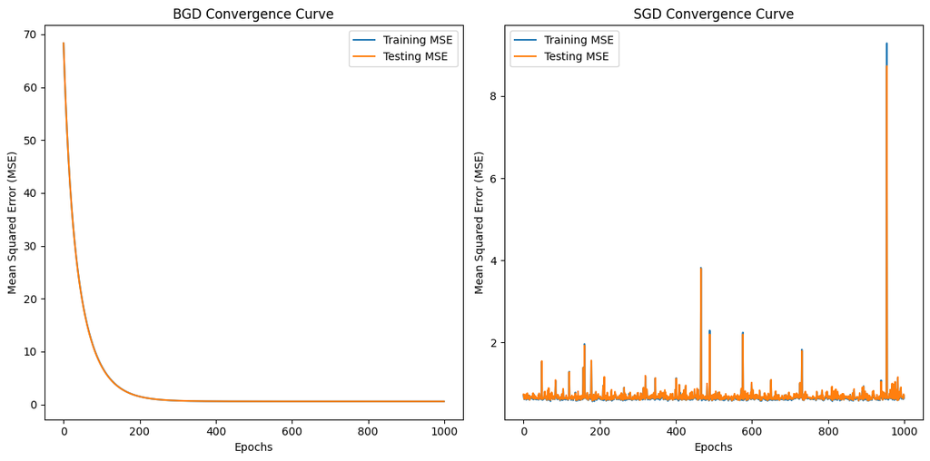

```python
# 实例化线性回归模型，分别使用 BGD 和 SGD 进行训练
model_bgd = LinearRegression(learning_rate=0.01, epochs=1000, method='batch')
model_bgd.fit(X_train, y_train, X_test, y_test)

model_sgd = LinearRegression(learning_rate=0.01, epochs=1000, method='stochastic')
model_sgd.fit(X_train, y_train, X_test, y_test)

# 绘制 MSE 收敛曲线
plt.figure(figsize=(12, 6))

# BGD 收敛曲线
plt.subplot(1, 2, 1)
plt.plot(model_bgd.train_history, label='Training MSE')
plt.plot(model_bgd.test_history, label='Testing MSE')
plt.title('BGD Convergence Curve')
plt.xlabel('Epochs')
plt.ylabel('Mean Squared Error (MSE)')
plt.legend()

# SGD 收敛曲线
plt.subplot(1, 2, 2)
plt.plot(model_sgd.train_history, label='Training MSE')
plt.plot(model_sgd.test_history, label='Testing MSE')
plt.title('SGD Convergence Curve')
plt.xlabel('Epochs')
plt.ylabel('Mean Squared Error (MSE)')
plt.legend()

plt.tight_layout()
plt.show()
```

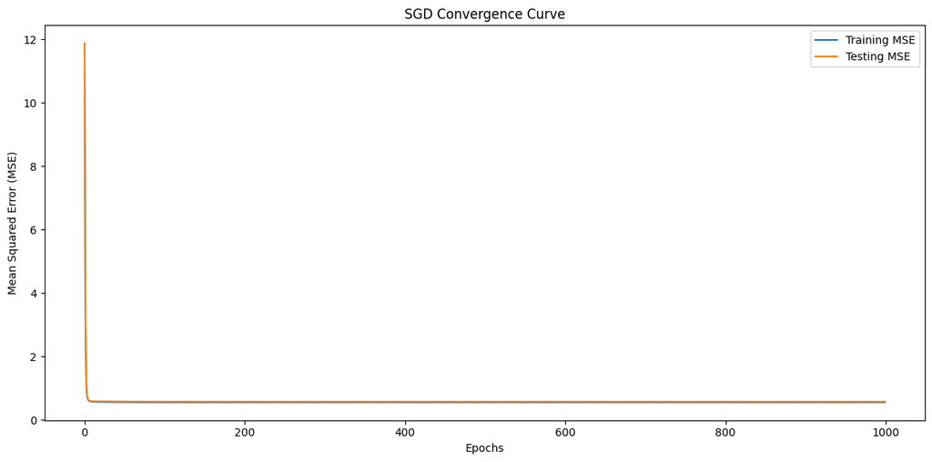

```python
# 实例化线性回归模型，分别使用 BGD 和 SGD 进行训练
model_sgd = LinearRegression(learning_rate=0.0001, epochs=1000, method='stochastic')
model_sgd.fit(X_train, y_train, X_test, y_test)

# 绘制 MSE 收敛曲线
plt.figure(figsize=(12, 6))


# SGD 收敛曲线
plt.subplot(1, 1, 1)
plt.plot(model_sgd.train_history, label='Training MSE')
plt.plot(model_sgd.test_history, label='Testing MSE')
plt.title('SGD Convergence Curve')
plt.xlabel('Epochs')
plt.ylabel('Mean Squared Error (MSE)')
plt.legend()

plt.tight_layout()
plt.show()
```

**BGD：**

```
Learning rate = 0.001, Final Test MSE = 5.777137966624932
Learning rate = 0.01, Final Test MSE = 0.5813356226662317
Learning rate = 0.1, Final Test MSE = 0.5809730261632597
Learning rate = 0.2, Final Test MSE = 0.5794804986759675
Learning rate = 0.3, Final Test MSE = 0.5793889359582413
Learning rate = 0.4, Final Test MSE = 0.5793887629697407
Learning rate = 0.5, Final Test MSE = 0.579387515573961
Learning rate = 0.6, Final Test MSE = 0.579387493672597
```

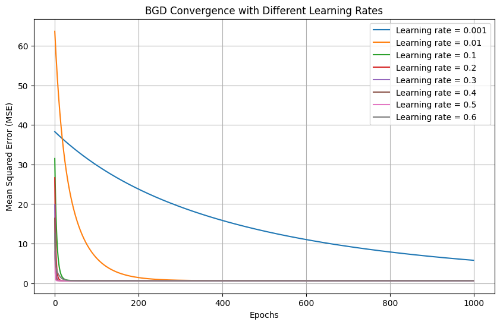

```python
# 学习率列表
learning_rates = [0.001, 0.01, 0.1, 0.2, 0.3, 0.4, 0.5, 0.6]

# 用于存储不同学习率下的 MSE 收敛曲线和最终MSE
history_list = []
final_mse_list = []

# 使用不同学习率训练模型并记录历史和最终的MSE
for lr in learning_rates:
    model = LinearRegression(learning_rate=lr, epochs=1000, method='batch')
    model.fit(X_train, y_train, X_test, y_test)
    history_list.append(model.test_history)  # 保存每个学习率的收敛曲线

    # 记录每个学习率下训练结束时的 MSE
    final_mse = model.test_history[-1]
    final_mse_list.append(final_mse)
    print(f'Learning rate = {lr}, Final Test MSE = {final_mse}')

# 绘制不同学习率下的收敛曲线
plt.figure(figsize=(10, 6))

for i, lr in enumerate(learning_rates):
    plt.plot(history_list[i], label=f'Learning rate = {lr}')

plt.title('BGD Convergence with Different Learning Rates')
plt.xlabel('Epochs')
plt.ylabel('Mean Squared Error (MSE)')
plt.legend()
plt.grid(True)
plt.show()
```

发现学习率依次提高到0.6时，模型收敛的速度越来越快，也都能最终趋于稳定。 现在取学习率为0.7

```
Learning rate = 0.7, Final Test MSE = 2.9115610330635656e+201
```

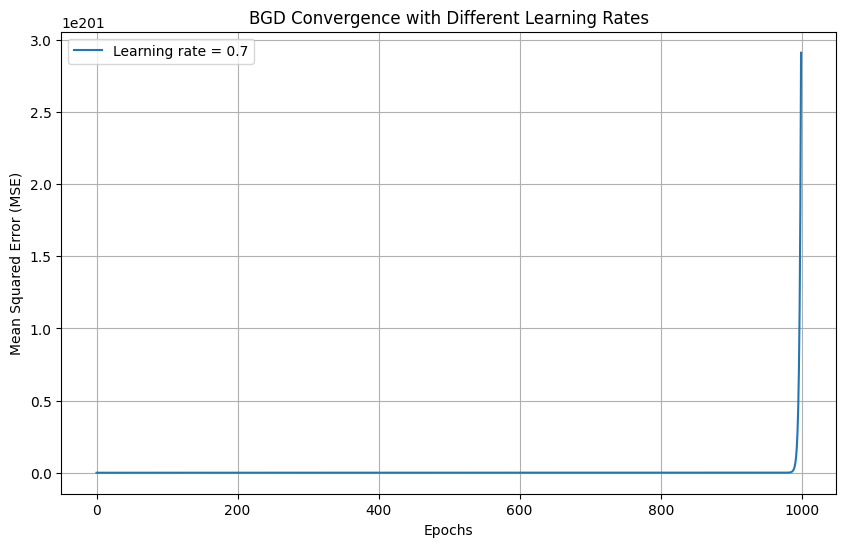

```python
# 学习率列表
learning_rates = [0.7]

# 用于存储不同学习率下的 MSE 收敛曲线和最终MSE
history_list = []
final_mse_list = []

# 使用不同学习率训练模型并记录历史和最终的MSE
for lr in learning_rates:
    model = LinearRegression(learning_rate=lr, epochs=1000, method='batch')
    model.fit(X_train, y_train, X_test, y_test)
    history_list.append(model.test_history)  # 保存每个学习率的收敛曲线

    # 记录每个学习率下训练结束时的 MSE
    final_mse = model.test_history[-1]
    final_mse_list.append(final_mse)
    print(f'Learning rate = {lr}, Final Test MSE = {final_mse}')

# 绘制不同学习率下的收敛曲线
plt.figure(figsize=(10, 6))

for i, lr in enumerate(learning_rates):
    plt.plot(history_list[i], label=f'Learning rate = {lr}')

plt.title('BGD Convergence with Different Learning Rates')
plt.xlabel('Epochs')
plt.ylabel('Mean Squared Error (MSE)')
plt.legend()
plt.grid(True)
plt.show()
```

综上所述：我得出的结论最优学习率结论是：**对于BGD方法，学习率取0.4-0.6之间较为合适，既能保证收敛速度，又能在一定程度上保证稳定性。**

**SGD：**

```
Learning rate = 1e-05, Final Test MSE = 0.5802847568017369
Learning rate = 0.0001, Final Test MSE = 0.5825284112168321
Learning rate = 0.001, Final Test MSE = 0.5809078546562286
Learning rate = 0.01, Final Test MSE = 0.6403267069407775
```

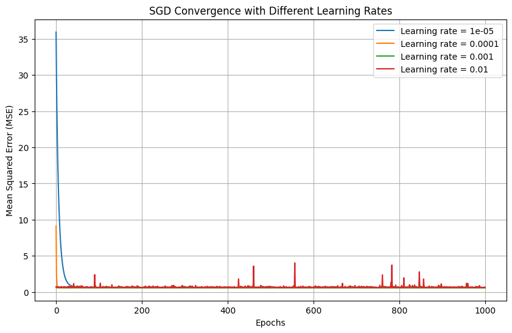

```python
# 学习率列表
learning_rates = [0.00001, 0.0001, 0.001, 0.01]
# 用于存储不同学习率下的 MSE 收敛曲线和最终MSE
history_list = []
final_mse_list = []

# 使用不同学习率训练模型并记录历史和最终的MSE
for lr in learning_rates:
    model = LinearRegression(learning_rate=lr, epochs=1000, method='stochastic')
    model.fit(X_train, y_train, X_test, y_test)
    history_list.append(model.test_history)  # 保存每个学习率的收敛曲线

    # 记录每个学习率下训练结束时的 MSE
    final_mse = model.test_history[-1]
    final_mse_list.append(final_mse)
    print(f'Learning rate = {lr}, Final Test MSE = {final_mse}')

# 绘制不同学习率下的收敛曲线
plt.figure(figsize=(10, 6))

for i, lr in enumerate(learning_rates):
    plt.plot(history_list[i], label=f'Learning rate = {lr}')

plt.title('SGD Convergence with Different Learning Rates')
plt.xlabel('Epochs')
plt.ylabel('Mean Squared Error (MSE)')
plt.legend()
plt.grid(True)
plt.show()
```

分析图像与前面输出的数据可知，学习率较低时（如1e-5，1e-4等），能得到一稳定的收敛过程，学习率较高时（0.01），从收敛图像可以看出，不能正常稳定收敛，综合分析得出结论：**对于SGD算法的回归模型，取学习率为1e-4数量级较为合适，在尽可能保证稳定收敛的情况下保证了收敛速度。**

## 2.中级要求实现：探究回归模型在机器学习和统计学上的差异。

- 回归模型在机器学习领域和统计学领域中都十分常用，而且使用方法也相似，但其实际的含义具有本质的区别。本部分我将从总结差异、代码实现、综合评价三个方面来讨论此话题。

### 1. 总结差异

对于**机器学习**而言，主要目标是**预测**。通过算法对训练数据进行优化，最小化损失函数（如均方误差MSE）。它通常依赖于大规模计算，从而能够处理高维、复杂、非线性数据，但其解释性相对较弱，本质上还是一种输入与输出之间的预测，在执行过程中会更注重性能与预测精度。**在执行形式上来说，机器学习采取迭代的方式来逼近最优解**。

而对于**统计学**而言：主要目标是**解释**。统计方法更注重模型的假设和推断，关注变量之间的关系、模型拟合优度、假设检验、置信区间等。在统计学中，更加注重因果推断，基于假设的线性模型通常有一定的解释性。**在执行形式上来说，统计学方法通过严格的数学过程推导，能够静态地一次性地给出最终的参数估计**。

### 2. 统计学方法代码实现

对于本问题，我们完全可以用统计学中的最小二乘法来完成多元线性回归，来得到多个自变量（特征）对一个因变量（标签）的影响。其数学关键过程如下： 回归模型表达式：$$y=X\beta+\epsilon $$

- y 是 m×1 的因变量向量（目标值），
- X 是 m×n的特征矩阵，
- β 是 n×1的回归系数向量，
- ϵ 是 m×1的误差项。
- 目标是通过最小二乘法估计 β，即最小化以下损失函数： $$\min_\beta\|y-X\beta\|^2=(y-X\beta)^T(y-X\beta)$$ 解这个问题的闭式解为： $$\hat{\beta}=(X^TX)^{-1}X^Ty$$ 其中，$\hat{\beta}$ 是最小二乘法得到的回归系数估计。

```python
import numpy as np
import pandas as pd
import matplotlib.pyplot as plt
from sklearn.model_selection import train_test_split
from sklearn.preprocessing import StandardScaler

# 读取数据集
data = pd.read_csv("winequality-white.csv")

# 划分特征和标签
X = data.iloc[:, :-1].values
y = data.iloc[:, -1].values

X_train, X_test, y_train, y_test = train_test_split(X, y, test_size=0.2, stratify=y, random_state=42)
scaler = StandardScaler()
X_train = scaler.fit_transform(X_train)
# 为了向量相乘方便，在训练集X左侧添加全为1的一列
X_train = np.hstack([np.ones((X_train.shape[0], 1)), X_train])


X_test = scaler.transform(X_test)
# 在测试集X左侧也添加全为1的一列
X_test = np.hstack([np.ones((X_test.shape[0], 1)), X_test])

# OLS最小二乘法的实现
def ordinary_least_squares(X, y):
    # 计算 (X^T X)^(-1) X^T y
    beta = np.linalg.inv(X.T.dot(X)).dot(X.T).dot(y)
    return beta

# 通过OLS获得统计学参数估计
beta_hat = ordinary_least_squares(X_train, y_train)

# 预测函数
def predict(X, beta):
    return np.dot(X, beta)

# 在训练集上进行预测
y_train_pred = predict(X_train, beta_hat)
# 在测试集上进行预测
y_test_pred = predict(X_test, beta_hat)

# 计算训练集 MSE
mse_train = np.mean((y_train_pred - y_train) ** 2)
# 计算测试集 MSE
mse_test = np.mean((y_test_pred - y_test) ** 2)

# 输出结果
print(f'Train MSE: {mse_train}')
print(f'Test MSE: {mse_test}')

# 打印回归系数
print("Estimated coefficients (beta):")
print(beta_hat)
```

```
Train MSE: 0.5594597855221156
Test MSE: 0.5793874861750062
Estimated coefficients (beta):
[ 5.87799898e+00  4.80574846e-02 -1.90743596e-01  1.42325673e-02
  4.03369303e-01 -1.27796332e-02  5.74469443e-02 -1.52794395e-03
 -4.29130744e-01  1.04678113e-01  6.85364515e-02  2.50810544e-01]
```

### 3. 综合评价

可以观察到，对于本数据集来说，使用统计学的方法获得回归模型预测的结果更方便，同时也具有相持平的精度（**在相同的数据划分下测试集预测MSE都在0.58左右**），**但这并不意味着在线性回归模型领域，统计学方法就优于机器学习基于梯度下降的方法。我对此查阅资料，对两者之间有以下几点联系与区别的思考**：

**统计学方法相对于机器学习的优势：**

对于规模不大、且特征数合适的数据集，线性回归具有很高的计算效率和解释性。

**统计学方法相对于机器学习的局限性：**

1. 对于数据规模的局限性：

当数据规模很大时（例如数百万个样本和特征），最小二乘法的计算复杂度会变得很高。OLS 需要计算大规模的矩阵的逆，这个操作的时间复杂度为 O(n^3)，当 n 很大时，最小二乘法就不行了；而此时机器学习的梯度下降就具有优势：梯度下降是增量式的优化方法，特别是随机梯度下降（SGD），每次只对单个样本或一小批样本进行更新。相比于 OLS，它不会出现高复杂度，其内存需求更低，适合处理大规模数据集，尤其是在分布式环境下。

2. 对于数据形状的局限性：

在高维数据（特征数量大于样本数量）情况下，矩阵$ X^TX$可能是奇异的，这将导致 OLS 解存在多重共线性问题，回归系数估计变得不稳定；而我通过查阅资料了解到，机器学习引入了正则化技术，如Lasso和Ridge回归，可以在高维问题中有效防止过拟合。这些正则化方法通过增加惩罚项使得模型更加稳定，而它们通常是通过梯度下降或其他数值方法来求解的。

**两种方法执行上的差异：**

最小二乘法通常假设数据是静态的，需要在数据集固定后一次性计算出回归系数，不能应对动态更新的过程；而对于机器学习而言，数据是在过程中不断更新的（比如要估计的参数），梯度下降特别是随机梯度下降非常适合在线学习场景。它可以在数据逐渐到达时，实时更新模型，而不必重新处理整个数据集。这在需要连续学习或数据流场景（如推荐系统、实时预测）中特别有用。

## 3.高级要求实现：实现岭回归算法，求解训练样本的岭回归模型，平均训练误差和平均测试误差

对于本题而言，由于之前已经实现了原始线性回归模型的BGD和SGD，因此我将在此基础上修改来实现BGD和SGD方法的岭回归模型。

### 1. 岭回归模型分析

岭回归的损失函数是： $$J(\theta)=\frac1{2m}\sum_{i=1}^m(h_\theta(x^{(i)})-y^{(i)})^2+\lambda\sum_{j=1}^n\theta_j^2$$ 其中：$\lambda$是正则化参数，控制惩罚项的强度。$\theta_j$是回归系数，不包括偏置项$\theta_0$。和第一部分内容中的类似，$$h_\theta ( x^{( i) }) = \theta ^Tx^{( i) }$$ 是线性回归的预测值。

### 2. 岭回归模型编程实现与结果呈现

相对之前的模型，在梯度下降的过程中，只需在计算梯度时加上正则化项即可。**具体来说，对于批量梯度下降和随机梯度下降的实现，可以修改梯度计算的部分来实现岭回归**。下面是完整代码与介绍（此代码基本和前面相同，只多了一个参数$\lambda $和修改了梯度更新项）：

**基于SGD的岭回归实现**

```
Learning rate = 1e-05, 平均训练误差 = 0.5629041065284848
Learning rate = 1e-05, 平均测试误差 = 0.5823514454010404
Learning rate = 0.0001, 平均训练误差 = 0.5632489226377
Learning rate = 0.0001, 平均测试误差 = 0.5827653700343716
Learning rate = 0.001, 平均训练误差 = 0.5743602888060096
Learning rate = 0.001, 平均测试误差 = 0.5965139442221404
Learning rate = 0.01, 平均训练误差 = 0.6555734210378469
Learning rate = 0.01, 平均测试误差 = 0.6777853919859541
```

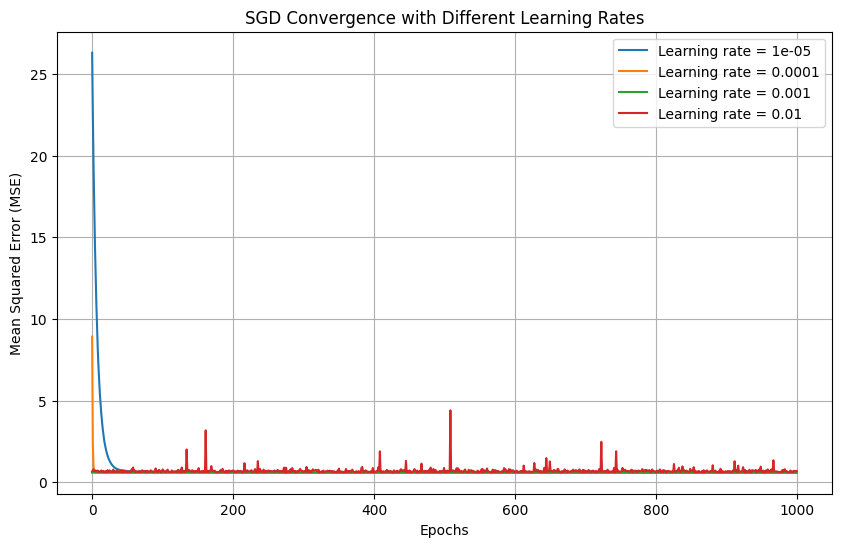

```python
#数据处理略
#岭回归机器学习实现
class Ridgeregression:
    def __init__(self, learning_rate=0.01, epochs=1000, method='batch', lambda_=0.1):
        self.alpha = learning_rate
        self.epochs = epochs
        self.method = method  # 'batch' for BGD, 'stochastic' for SGD
        self.lambda_ = lambda_  # 正则化参数

    def fit(self, X_train, y_train, X_test, y_test):
        self.m, self.n = X_train.shape
        # 随机初始化回归系数
        self.theta = np.random.randn(self.n)
        self.X_train = X_train
        self.y_train = y_train
        self.X_test = X_test
        self.y_test = y_test

        # 历史记录 MSE
        self.train_history = []
        self.test_history = []

        for epoch in range(self.epochs):
            if self.method == 'batch':
                self.batch_gradient_descent()
            elif self.method == 'stochastic':
                self.stochastic_gradient_descent()

            # 记录每次迭代训练集和测试集的 MSE
            train_mse = self.mean_squared_error(self.predict(self.X_train), self.y_train)
            test_mse = self.mean_squared_error(self.predict(self.X_test), self.y_test)
            self.train_history.append(train_mse)
            self.test_history.append(test_mse)

    def batch_gradient_descent(self):
        # 加入正则化的梯度计算: m/1* XT (Xθ−y) + λθ
        gradients = (1 / self.m) * self.X_train.T.dot(self.X_train.dot(self.theta) - self.y_train)
        # 对 theta 的正则化，不对偏置项 (theta_0) 进行正则化
        gradients += self.lambda_ * np.r_[[0], self.theta[1:]]
        self.theta -= self.alpha * gradients

    def stochastic_gradient_descent(self):
        for i in range(self.m):
            random_idx = np.random.randint(self.m)
            xi = self.X_train[random_idx:random_idx + 1]
            yi = self.y_train[random_idx:random_idx + 1]
            gradients = -2 * xi.T.dot(yi - xi.dot(self.theta))
            # 对 theta 的正则化，不对偏置项 (theta_0) 进行正则化
            gradients += self.lambda_ * np.r_[[0], self.theta[1:]]
            self.theta -= self.alpha * gradients

    def predict(self, X):
        return np.dot(X, self.theta)

    def mean_squared_error(self, predictions, y):
        return np.mean((predictions - y) ** 2)

# 学习率列表
learning_rates = [0.00001, 0.0001, 0.001, 0.01]
# 用于存储不同学习率下的 MSE 收敛曲线和最终MSE
history_list = []
final_mse_list0 = []
final_mse_list = []


# 使用不同学习率训练模型并记录历史和最终的MSE
for lr in learning_rates:
    model = Ridgeregression(learning_rate=lr, epochs=1000, method='stochastic', lambda_=0.1)
    model.fit(X_train, y_train, X_test, y_test)
    history_list.append(model.test_history)  # 保存每个学习率的收敛曲线

    # 记录每个学习率下训练结束时的平均训练误差
    final_mse = model.train_history[-1]
    final_mse_list0.append(final_mse)
    print(f'Learning rate = {lr}, 平均训练误差 = {final_mse}')

    # 记录每个学习率下训练结束时的平均测试误差
    final_mse = model.test_history[-1]
    final_mse_list.append(final_mse)
    print(f'Learning rate = {lr}, 平均测试误差 = {final_mse}')
# 绘制不同学习率下的收敛曲线
plt.figure(figsize=(10, 6))

for i, lr in enumerate(learning_rates):
    plt.plot(history_list[i], label=f'Learning rate = {lr}')

plt.title('SGD Convergence with Different Learning Rates')
plt.xlabel('Epochs')
plt.ylabel('Mean Squared Error (MSE)')
plt.legend()
plt.grid(True)
plt.show()
```

需要注意，在学习率取0.01时，基于SGD的岭回归模型无法收敛，我们关注有效的学习率下的模型性能即可。由上述数据和图像可知，当学习率取合适值时，我们在测试集的MSE为0.58左右。

**基于BGD的岭回归实现：**

```
Learning rate = 0.001, 平均训练误差 = 8.375169920537292
Learning rate = 0.001, 平均测试误差 = 8.382466910181424
Learning rate = 0.01, 平均训练误差 = 0.5699725567788604
Learning rate = 0.01, 平均测试误差 = 0.5884327762265763
Learning rate = 0.1, 平均训练误差 = 0.5657173708033658
Learning rate = 0.1, 平均测试误差 = 0.5847290687908113
Learning rate = 0.2, 平均训练误差 = 0.5657172971140226
Learning rate = 0.2, 平均测试误差 = 0.5847289949397615
Learning rate = 0.3, 平均训练误差 = 0.5657172971139599
Learning rate = 0.3, 平均测试误差 = 0.5847289949396988
Learning rate = 0.4, 平均训练误差 = 0.5657172971139599
Learning rate = 0.4, 平均测试误差 = 0.5847289949396989
Learning rate = 0.5, 平均训练误差 = 0.5657172971139599
Learning rate = 0.5, 平均测试误差 = 0.5847289949396989
Learning rate = 0.6, 平均训练误差 = 1.2493729463069692
Learning rate = 0.6, 平均测试误差 = 1.2617799028467804
```

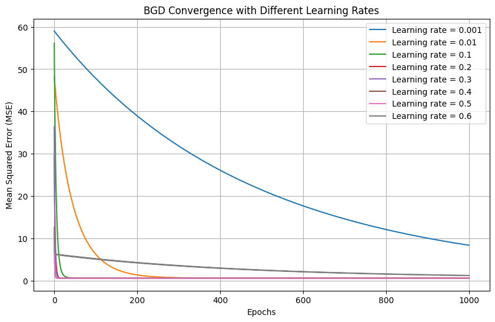

```python
# 学习率列表
learning_rates = [0.001, 0.01, 0.1, 0.2, 0.3, 0.4, 0.5, 0.6]
# 用于存储不同学习率下的 MSE 收敛曲线和最终MSE
history_list = []
final_mse_list0 = []
final_mse_list = []


# 使用不同学习率训练模型并记录历史和最终的MSE
for lr in learning_rates:
    model = Ridgeregression(learning_rate=lr, epochs=1000, method='batch', lambda_=0.1)
    model.fit(X_train, y_train, X_test, y_test)
    history_list.append(model.test_history)  # 保存每个学习率的收敛曲线

    # 记录每个学习率下训练结束时的平均训练误差
    final_mse = model.train_history[-1]
    final_mse_list0.append(final_mse)
    print(f'Learning rate = {lr}, 平均训练误差 = {final_mse}')

    # 记录每个学习率下训练结束时的平均测试误差
    final_mse = model.test_history[-1]
    final_mse_list.append(final_mse)
    print(f'Learning rate = {lr}, 平均测试误差 = {final_mse}')
# 绘制不同学习率下的收敛曲线
plt.figure(figsize=(10, 6))

for i, lr in enumerate(learning_rates):
    plt.plot(history_list[i], label=f'Learning rate = {lr}')

plt.title('BGD Convergence with Different Learning Rates')
plt.xlabel('Epochs')
plt.ylabel('Mean Squared Error (MSE)')
plt.legend()
plt.grid(True)
plt.show()
```

需要注意的是，在学习率为0.6时，模型似乎不能正常收敛，学习率为0.001时，模型的收敛速度过慢，因此当我们评价基于BSD的岭回归模型时，专注这两者之间较为合适的学习率下的模型性能即可，即当学习率为0.01，0.1，……0.5时，模型都在1000轮下达到了可观的收敛结果，证明了岭回归的有效性。